# Ford GoBike Trip Analysis by Time and User Type

## Investigation Overview

In this investigation, I will analyze when the most bike trips were taken in terms of time of day, day of the week, or month of year. Also I will research the average duration for a bike trip and whether the type of user affects the number of trips or average duration.

## Dataset Overview

The bike-share dataset contains 2,506,983 entries of bike trips in the San Francisco Bay area for 2019. It has 13 different columns of variables including trip duration, start time and date, end time and date, start station information, end station information, bike ID, and user type, whether Subscriber (Member) or Customer (Casual).

I created new columns for time of day (hour), day of the week (weekday), and month of year (month) from the start time and date data for easier analysis. I removed one outlier that had an unusually long duration. I also converted the duration from seconds to minutes and added the data as a new column, duration_mins, to the dataframe for easier interpretation.

```python
# Import all packages and set plots to be embedded inline
import numpy as np
import pandas as pd
import matplotlib.pyplot as plt
import seaborn as sb

%matplotlib inline

# suppress warnings from final output
import warnings
warnings.simplefilter("ignore")
```

```python
# load in ride info for months 1 - 4 into dictionary of dataframes with fordgobike-tripdata.csv filenames
rides_dict = {}
for x in range(1,5):
    filename = str(20190) + str(x) + '-fordgobike-tripdata.csv'
    keyname = 'rides_0' + str(x)
    rides_dict[keyname] = pd.read_csv(filename)
    #print(keyname, filename)
```

```python
# load in ride info for months 5 to 12 with baywheels-tripdata.csv filenames
# Specify data types for columns user_type and bike_share and set low-memory to False because of warning message
for x in range(5,13):
    if x < 10:
        month = str(0) + str(x)
    else:
        month = str(x)
    filename = str(2019)+ month + '-baywheels-tripdata.csv'
    keyname = 'rides_'+ month
    rides_dict[keyname] = pd.read_csv(filename,dtype={'user_type':str, 'bike_share_for_all':str},low_memory=False)
    #print(keyname, filename)
```

```python
# Drop extra column of rental_access_method for months 6, 7, 11, and 12
extra_months = ['rides_06', 'rides_07', 'rides_11', 'rides_12']
for m in extra_months:
    rides_dict[m].drop('rental_access_method', axis = 1, inplace = True)
    #print(m, rides_dict[m].shape)
```

```python
# Drop bike_share_for_all_trip column from months 1 thru 11 since month 12 is missing it
for m in range(1,12):
    if m < 10:
        month = str(0) + str(m)
    else:
        month = str(m)
    keyname = 'rides_'+ month
    rides_dict[keyname].drop('bike_share_for_all_trip', axis = 1, inplace = True)
    #print(keyname, rides_dict[keyname].shape)
```

```python
# Build a list of dataframes and concat together dataframes
rides_list = []
total = 0
for keyname, df in rides_dict.items():
    total += df.shape[0]
    rides_list.append(df)
#print('Total: ', total)
rides = pd.concat(rides_list, ignore_index=True)
```

```python
# Change start_time and end_time to datetime
rides['start_time'] = pd.to_datetime(rides['start_time'])
rides['end_time'] = pd.to_datetime(rides['end_time'])
```

```python
# Change user_type to category type
utypes = pd.api.types.CategoricalDtype(ordered = True, categories = ['Customer','Subscriber'])
rides['user_type'] = rides['user_type'].astype('category')
```

```python
# Add columns for time of day (hour), day of the week (weekday), and month of year (month)
rides['hour'] = rides['start_time'].dt.hour
rides['weekday'] = rides['start_time'].dt.dayofweek
rides['month'] = rides['start_time'].dt.month
#rides.head()
```

```python
# Set up days of week and month labels for plots
# rides = pd.read_csv('rides.csv')
days = [0, 1, 2, 3, 4, 5, 6]
day_names = ['Mon', 'Tues', 'Wed', 'Thur', 'Fri', 'Sat', 'Sun']
months = [0, 1, 2, 3, 4, 5, 6, 7, 8, 9, 10, 11]
month_names = ['Jan', 'Feb', 'Mar', 'Apr', 'May', 'Jun', 'Jul', 'Aug', 'Sep', 'Oct', 'Nov', 'Dec']
```

## Number of Bike Trips by Time of Day

The distribution of bike trips taken each hour of the day appears roughly bimodal, with the number of trips peaking around 8am and around 5pm (17hr), which coincides with the start and end of a workday.

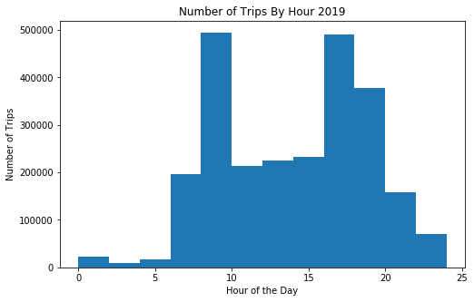

```python
# Plot trip counts based on time of day (hour)
plt.figure(figsize=[8,5])
binsize = 2
bin_edges = np.arange(0, 25, binsize)
plt.hist(data=rides, x = 'hour', bins=bin_edges)
plt.xlabel('Hour of the Day')
plt.ylabel('Number of Trips')
plt.title('Number of Trips By Hour 2019')
plt.show()
```

## Number of Bike Trips by Day of the Week

The highest number of bike trips occurs during the work week with significantly less on the weekend. Tuesdays and Thursdays show slightly higher numbers than the other work days.

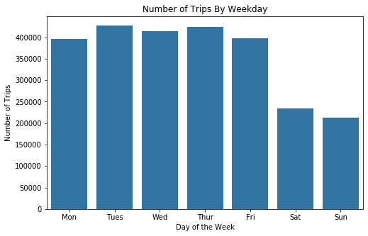

```python
# Plot trip counts based on day of the week (weekday)
base_color = sb.color_palette()[0]
plt.figure(figsize=[8,5])
sb.countplot(data=rides, x = 'weekday', color = base_color)
plt.xticks(days, day_names)
plt.xlabel('Day of the Week')
plt.ylabel('Number of Trips')
plt.title('Number of Trips By Weekday')
plt.show()
```

## Number of Bike Trips by Month

The largest number of trips occured in March, April, July, and October of 2019.

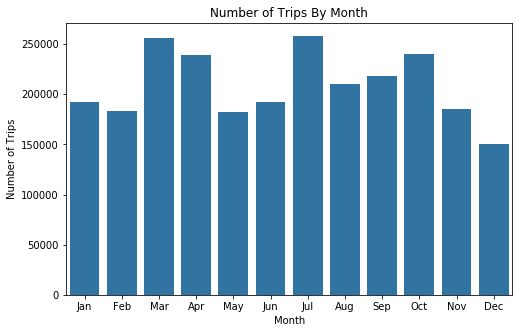

```python
# Plot trip counts based on month of the year
base_color = sb.color_palette()[0]
plt.figure(figsize=[8,5])
sb.countplot(data=rides, x = 'month', color = base_color)
plt.xticks(months, month_names)
plt.ylabel('Number of Trips')
plt.title('Number of Trips By Month')
plt.xlabel('Month')

plt.show()
```

## Number of Bike Trips by User Type

The number of bike trips by subscribers, in other words people who have become members, greatly outnumber those of customers, who are just casual users.

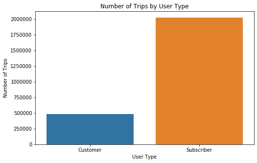

```python
# Plot trip counts based on user type

plt.figure(figsize=[8,5])
sb.countplot(data=rides, x = 'user_type')
plt.xlabel('User Type')
plt.ylabel('Number of Trips')
plt.title('Number of Trips by User Type')
plt.show()
```

```python
# Convert duration from seconds to minutes for easier interpretation
rides['duration_mins'] = rides['duration_sec']/60
```

## Number of Trips by Duration

The plot of number of trips by duration shows a right skewed distribution with greater number bike trips on the lower end. The average duration is 13 minutes.

```python
# Drop the one outlier since it seems an anomaly
rides.drop(2481276, inplace=True)
#high_outliers = (rides['duration_mins']>1500)
#print(high_outliers.sum())
```

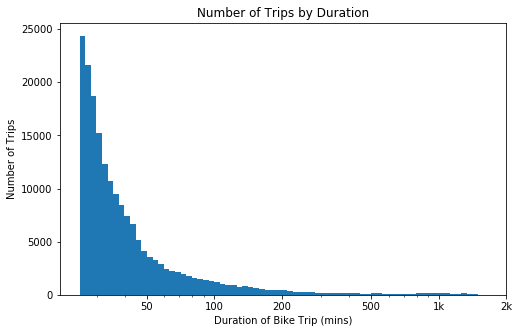

```python
# Try plot without outlier
log_binsize = 0.025
bins = 10 ** np.arange(1.4, np.log10(rides['duration_mins'].max())+log_binsize, log_binsize)

plt.figure(figsize=[8, 5])
plt.hist(data = rides, x = 'duration_mins', bins = bins)
plt.xscale('log')
plt.xticks([50, 100, 200, 500, 1e3, 2e3], [50, 100, 200, 500, '1k', '2k'])
plt.xlabel('Duration of Bike Trip (mins)')
plt.ylabel('Number of Trips')
plt.title('Number of Trips by Duration')
plt.show()
```

## Count of Trips by Hour, Weekday, and Month Grouped by User Type

The plot of number of trips by hour shows the same pattern of peaking at 8am and 5pm for both subscribers and customers. The plot by day of the week shows that subscribers use the bikes more during the work week and less on the weekend. The customers' usage is fairly consistently the same across the days. The plot by month shows the subscriber's usage peaks in March, April, July, and October. The customer's usage shows a slow increase from July to peaking in December with a slight dip in November.

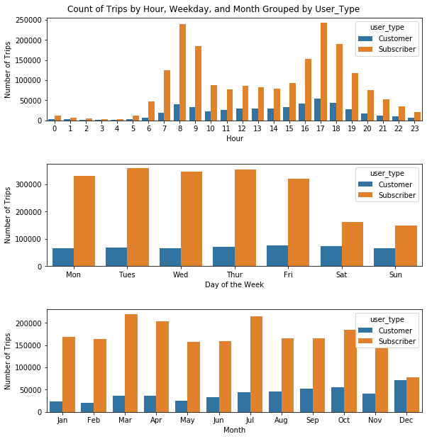

```python
# Plot three plots of user type versus hour, weekday, and month
fig = plt.figure(figsize=[9,9])
fig.suptitle('Count of Trips by Hour, Weekday, and Month Grouped by User_Type')

# Subplot 1: hour vs user type
plt.subplot(3,1,1)
sb.countplot(data = rides, x = 'hour', hue = 'user_type')
plt.ylabel('Number of Trips')
plt.xlabel('Hour')

# Subplot 2: weekday vs user type
ax = plt.subplot(3,1,2)
sb.countplot(data = rides, x = 'weekday', hue = 'user_type')
plt.xticks(days, day_names)
plt.xlabel('Day of the Week')
plt.ylabel('Number of Trips')

# Subplot 3: month vs user type
ax = plt.subplot(3,1,3)
sb.countplot(data = rides, x = 'month', hue = 'user_type')
plt.xticks(months, month_names)
plt.ylabel('Number of Trips')
plt.xlabel('Month')

fig.tight_layout(pad = 3.0)
plt.show()
```

## Duration by User Type

The average duration seems slightly higher for customers than for subscribers.

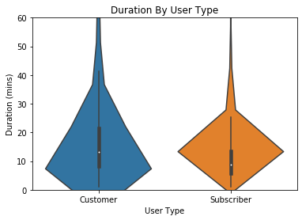

```python
# Plot violinplots to see if user type makes a difference in average duration

plt.ylim(0,60)
sb.violinplot(data = rides, x = 'user_type', y = 'duration_mins')
plt.xlabel('User Type')
plt.ylabel('Duration (mins)')
plt.title('Duration By User Type');
```

## Duration versus Time of Day by User Type

When looking by time of day, customers have higher average duration than subscribers. peaking around the middle of the day from 10am to 4pm.

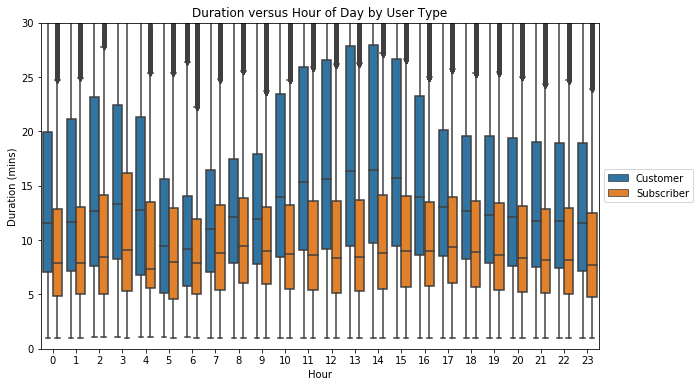

```python
#Plot Duration verus hour of day by user type
plt.figure(figsize=[10,6])
plt.ylim(0,30)
sb.boxplot(data = rides, x = 'hour', y = 'duration_mins', hue='user_type')
plt.xlabel('Hour')
plt.ylabel('Duration (mins)')
plt.title('Duration versus Hour of Day by User Type')
plt.legend(loc = 6, bbox_to_anchor = (1.0, 0.5));
```

## Duration versus Day of Week by User Type

When looking by day of the week, customers have a slightly higher average duration subscribers, peaking on the weekend.  
The average duration for subscribers does not vary by day of the week.

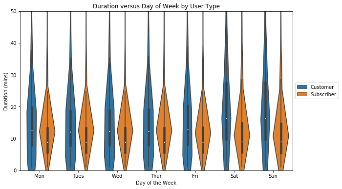

```python
#Plot Duration verus day of the week by user type
plt.figure(figsize=[10,6])
plt.ylim(0,50)
sb.violinplot(data = rides, x = 'weekday', y = 'duration_mins', hue='user_type')
plt.title('Duration versus Day of Week by User Type')
plt.xticks(days, day_names)
plt.xlabel('Day of the Week')
plt.ylabel('Duration (mins)')
plt.legend(loc = 6, bbox_to_anchor = (1.0, 0.5));
```

## Duration versus Month in the Year by User Type

When looking by month, the customers still have a higher average duration than subscribers, being highest in the months between March and July. The average duration for subscribers does not seem to vary by month.

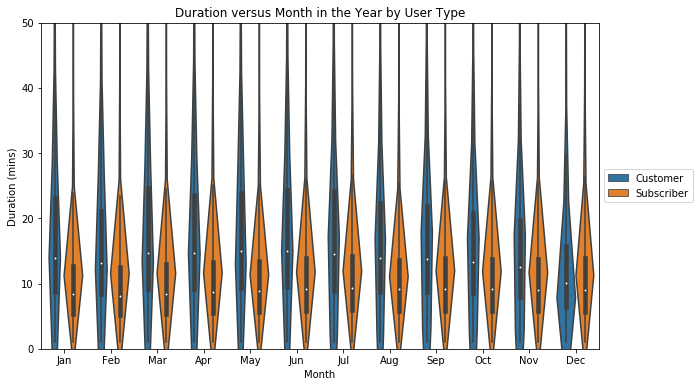

```python
#Plot Duration verus month by user type
plt.figure(figsize=[10,6])
plt.ylim(0,50)
sb.violinplot(data = rides, x = 'month', y = 'duration_mins', hue='user_type')
plt.title('Duration versus Month in the Year by User Type')
plt.xticks(months, month_names)
plt.ylabel('Duration (mins)')
plt.xlabel('Month')
plt.legend(loc = 6, bbox_to_anchor = (1.0, 0.5));
```